# Risk Factor Analysis

## Outcome Variable

**Outcome Variable:** whz

## Predictor Variables

**Intervention Variable:** exclfeed3

**Adjustment Set:**

- arm
- sex
- brthmon
- W_mage
- meducyrs
- feducyrs
- hhwealth_quart
- hfoodsec
- W_mhtcm
- W_mwtkg
- W_mbmi
- vagbrth
- W_gagebrth
- W_birthwt
- W_birthlen
- W_nrooms
- W_nchldlt5
- month
- W_parity
- impfloor
- impsan
- safeh20
- delta_W_mage
- delta_meducyrs
- delta_feducyrs
- delta_hhwealth_quart
- delta_hfoodsec
- delta_W_mhtcm
- delta_W_mwtkg
- delta_W_mbmi
- delta_vagbrth
- delta_W_gagebrth
- delta_W_birthwt
- delta_W_birthlen
- delta_W_nrooms
- delta_W_nchldlt5
- delta_month
- delta_W_parity
- delta_impfloor
- delta_impsan
- delta_safeh20

## Stratifying Variables

The analysis was stratified on these variable(s):

- agecat
- studyid
- country

## Data Summary

| agecat | studyid | country | exclfeed3 | n_cell | n | outcome_variable |
| --- | --- | --- | --- | --- | --- | --- |
| Birth | ki0047075b-MAL-ED | BANGLADESH | 1 | 130 | 202 | whz |
| Birth | ki0047075b-MAL-ED | BANGLADESH | 0 | 72 | 202 | whz |
| Birth | ki0047075b-MAL-ED | BRAZIL | 1 | 11 | 55 | whz |
| Birth | ki0047075b-MAL-ED | BRAZIL | 0 | 44 | 55 | whz |
| Birth | ki0047075b-MAL-ED | INDIA | 1 | 22 | 39 | whz |
| Birth | ki0047075b-MAL-ED | INDIA | 0 | 17 | 39 | whz |
| Birth | ki0047075b-MAL-ED | NEPAL | 1 | 8 | 25 | whz |
| Birth | ki0047075b-MAL-ED | NEPAL | 0 | 17 | 25 | whz |
| Birth | ki0047075b-MAL-ED | PERU | 1 | 47 | 218 | whz |
| Birth | ki0047075b-MAL-ED | PERU | 0 | 171 | 218 | whz |
| Birth | ki0047075b-MAL-ED | SOUTH AFRICA | 1 | 12 | 99 | whz |
| Birth | ki0047075b-MAL-ED | SOUTH AFRICA | 0 | 87 | 99 | whz |
| Birth | ki0047075b-MAL-ED | TANZANIA, UNITED REPUBLIC OF | 1 | 15 | 95 | whz |
| Birth | ki0047075b-MAL-ED | TANZANIA, UNITED REPUBLIC OF | 0 | 80 | 95 | whz |
| Birth | ki1000108-CMC-V-BCS-2002 | INDIA | 1 | 4 | 4 | whz |
| Birth | ki1000108-CMC-V-BCS-2002 | INDIA | 0 | 0 | 4 | whz |
| Birth | ki1000108-IRC | INDIA | 1 | 0 | 9 | whz |
| Birth | ki1000108-IRC | INDIA | 0 | 9 | 9 | whz |
| Birth | ki1000109-EE | PAKISTAN | 1 | 22 | 22 | whz |
| Birth | ki1000109-EE | PAKISTAN | 0 | 0 | 22 | whz |
| Birth | ki1000304b-SAS-CompFeed | INDIA | 1 | 310 | 325 | whz |
| Birth | ki1000304b-SAS-CompFeed | INDIA | 0 | 15 | 325 | whz |
| Birth | ki1017093b-PROVIDE | BANGLADESH | 1 | 381 | 532 | whz |
| Birth | ki1017093b-PROVIDE | BANGLADESH | 0 | 151 | 532 | whz |
| Birth | ki1101329-Keneba | GAMBIA | 1 | 1133 | 1282 | whz |
| Birth | ki1101329-Keneba | GAMBIA | 0 | 149 | 1282 | whz |
| Birth | ki1113344-GMS-Nepal | NEPAL | 1 | 352 | 422 | whz |
| Birth | ki1113344-GMS-Nepal | NEPAL | 0 | 70 | 422 | whz |
| Birth | kiGH5241-JiVitA-3 | BANGLADESH | 1 | 9636 | 10634 | whz |
| Birth | kiGH5241-JiVitA-3 | BANGLADESH | 0 | 998 | 10634 | whz |

[output cut: 64 more lines]

The following strata were considered:

- agecat: 24 months, studyid: ki0047075b-MAL-ED, country: BANGLADESH
- agecat: 24 months, studyid: ki0047075b-MAL-ED, country: BRAZIL
- agecat: 24 months, studyid: ki0047075b-MAL-ED, country: INDIA
- agecat: 24 months, studyid: ki0047075b-MAL-ED, country: NEPAL
- agecat: 24 months, studyid: ki0047075b-MAL-ED, country: PERU
- agecat: 24 months, studyid: ki0047075b-MAL-ED, country: SOUTH AFRICA
- agecat: 24 months, studyid: ki0047075b-MAL-ED, country: TANZANIA, UNITED REPUBLIC OF
- agecat: 24 months, studyid: ki1000108-CMC-V-BCS-2002, country: INDIA
- agecat: 24 months, studyid: ki1000108-IRC, country: INDIA
- agecat: 24 months, studyid: ki1000109-EE, country: PAKISTAN
- agecat: 24 months, studyid: ki1017093b-PROVIDE, country: BANGLADESH
- agecat: 24 months, studyid: ki1101329-Keneba, country: GAMBIA
- agecat: 24 months, studyid: ki1113344-GMS-Nepal, country: NEPAL
- agecat: 24 months, studyid: kiGH5241-JiVitA-3, country: BANGLADESH
- agecat: 24 months, studyid: kiGH5241-JiVitA-4, country: BANGLADESH
- agecat: 6 months, studyid: ki0047075b-MAL-ED, country: BANGLADESH
- agecat: 6 months, studyid: ki0047075b-MAL-ED, country: BRAZIL
- agecat: 6 months, studyid: ki0047075b-MAL-ED, country: INDIA
- agecat: 6 months, studyid: ki0047075b-MAL-ED, country: NEPAL
- agecat: 6 months, studyid: ki0047075b-MAL-ED, country: PERU
- agecat: 6 months, studyid: ki0047075b-MAL-ED, country: SOUTH AFRICA
- agecat: 6 months, studyid: ki0047075b-MAL-ED, country: TANZANIA, UNITED REPUBLIC OF
- agecat: 6 months, studyid: ki1000108-CMC-V-BCS-2002, country: INDIA
- agecat: 6 months, studyid: ki1000108-IRC, country: INDIA
- agecat: 6 months, studyid: ki1000109-EE, country: PAKISTAN
- agecat: 6 months, studyid: ki1000304b-SAS-CompFeed, country: INDIA
- agecat: 6 months, studyid: ki1017093b-PROVIDE, country: BANGLADESH
- agecat: 6 months, studyid: ki1101329-Keneba, country: GAMBIA
- agecat: 6 months, studyid: ki1113344-GMS-Nepal, country: NEPAL
- agecat: 6 months, studyid: kiGH5241-JiVitA-3, country: BANGLADESH
- agecat: 6 months, studyid: kiGH5241-JiVitA-4, country: BANGLADESH
- agecat: Birth, studyid: ki0047075b-MAL-ED, country: BANGLADESH
- agecat: Birth, studyid: ki0047075b-MAL-ED, country: BRAZIL
- agecat: Birth, studyid: ki0047075b-MAL-ED, country: INDIA
- agecat: Birth, studyid: ki0047075b-MAL-ED, country: NEPAL
- agecat: Birth, studyid: ki0047075b-MAL-ED, country: PERU
- agecat: Birth, studyid: ki0047075b-MAL-ED, country: SOUTH AFRICA
- agecat: Birth, studyid: ki0047075b-MAL-ED, country: TANZANIA, UNITED REPUBLIC OF
- agecat: Birth, studyid: ki1000108-CMC-V-BCS-2002, country: INDIA
- agecat: Birth, studyid: ki1000108-IRC, country: INDIA
- agecat: Birth, studyid: ki1000109-EE, country: PAKISTAN
- agecat: Birth, studyid: ki1000304b-SAS-CompFeed, country: INDIA
- agecat: Birth, studyid: ki1017093b-PROVIDE, country: BANGLADESH
- agecat: Birth, studyid: ki1101329-Keneba, country: GAMBIA
- agecat: Birth, studyid: ki1113344-GMS-Nepal, country: NEPAL
- agecat: Birth, studyid: kiGH5241-JiVitA-3, country: BANGLADESH
- agecat: Birth, studyid: kiGH5241-JiVitA-4, country: BANGLADESH

### Dropped Strata

- agecat: Birth, studyid: ki1000108-CMC-V-BCS-2002, country: INDIA
- agecat: Birth, studyid: ki1000108-IRC, country: INDIA
- agecat: Birth, studyid: ki1000109-EE, country: PAKISTAN
- agecat: 6 months, studyid: ki1000108-CMC-V-BCS-2002, country: INDIA
- agecat: 6 months, studyid: ki1000108-IRC, country: INDIA
- agecat: 6 months, studyid: ki1000109-EE, country: PAKISTAN
- agecat: 24 months, studyid: ki1000108-CMC-V-BCS-2002, country: INDIA
- agecat: 24 months, studyid: ki1000108-IRC, country: INDIA
- agecat: 24 months, studyid: ki1000109-EE, country: PAKISTAN

## Methods Detail

We’re interested in the causal parameters $E[Y_a]$ for all values of $a \in \mathcal{A}$. These parameters represent the mean outcome if, possibly contrary to fact, we intervened to set all units to have $A=a$. Under the randomization and positivity assumptions, these are identified by the statistical parameters $\psi_a=E_W[E_{Y|A,W}(Y|A=a,W)]$. In addition, we’re interested in the mean of $Y$, $E[Y]$ under no intervention (the observed mean). We will estimate these parameters by using SuperLearner to fit the relevant likelihood factors – $E_{Y|A,W}(Y|A=a,W)$ and $p(A=a|W)$, and then updating our likelihood fit using a joint TMLE.

For unadjusted analyses ($W=\{\}$), initial likelihoods were estimated using Lrnr_glm to estimate the simple $E(Y|A)$ and Lrnr_mean to estimate $p(A)$. For adjusted analyses, a small library containing Lrnr_glmnet, Lrnr_xgboost, and Lrnr_mean was used.

Having estimated these parameters, we will then use the delta method to estimate relative risks and attributable risks relative to a prespecified baseline level of $A$.

# Results Detail

## Results Plots

[figure not shown]

[figure not shown]

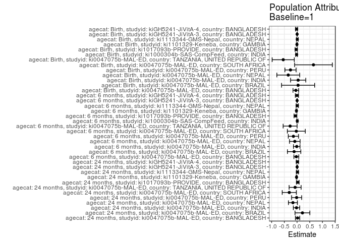

## Results Table

### Parameter: TSM

| agecat | studyid | country | intervention_level | baseline_level | estimate | ci_lower | ci_upper |
| --- | --- | --- | --- | --- | --- | --- | --- |
| Birth | ki0047075b-MAL-ED | BANGLADESH | 1 | NA | -0.8926337 | -1.0776025 | -0.7076648 |
| Birth | ki0047075b-MAL-ED | BANGLADESH | 0 | NA | -1.0134333 | -1.2642114 | -0.7626552 |
| Birth | ki0047075b-MAL-ED | BRAZIL | 1 | NA | 0.3903175 | -0.3127051 | 1.0933400 |
| Birth | ki0047075b-MAL-ED | BRAZIL | 0 | NA | 0.4271744 | 0.0403224 | 0.8140263 |
| Birth | ki0047075b-MAL-ED | INDIA | 1 | NA | -1.0218138 | -1.4408683 | -0.6027592 |
| Birth | ki0047075b-MAL-ED | INDIA | 0 | NA | -0.8880654 | -1.3580956 | -0.4180353 |
| Birth | ki0047075b-MAL-ED | NEPAL | 1 | NA | -0.4487500 | -0.8783289 | -0.0191711 |
| Birth | ki0047075b-MAL-ED | NEPAL | 0 | NA | -0.9570588 | -1.4394884 | -0.4746293 |
| Birth | ki0047075b-MAL-ED | PERU | 1 | NA | 0.2245759 | -0.0156813 | 0.4648330 |
| Birth | ki0047075b-MAL-ED | PERU | 0 | NA | -0.1017196 | -0.2439089 | 0.0404697 |
| Birth | ki0047075b-MAL-ED | SOUTH AFRICA | 1 | NA | -0.8047053 | -1.5762460 | -0.0331645 |
| Birth | ki0047075b-MAL-ED | SOUTH AFRICA | 0 | NA | -0.1690234 | -0.4121219 | 0.0740751 |
| Birth | ki0047075b-MAL-ED | TANZANIA, UNITED REPUBLIC OF | 1 | NA | 1.3432809 | 0.8902826 | 1.7962792 |
| Birth | ki0047075b-MAL-ED | TANZANIA, UNITED REPUBLIC OF | 0 | NA | 0.6968120 | 0.4655217 | 0.9281024 |
| Birth | ki1000304b-SAS-CompFeed | INDIA | 1 | NA | -0.6419787 | -0.8661092 | -0.4178481 |
| Birth | ki1000304b-SAS-CompFeed | INDIA | 0 | NA | -1.0901282 | -1.7027393 | -0.4775170 |
| Birth | ki1017093b-PROVIDE | BANGLADESH | 1 | NA | -1.2673465 | -1.3556319 | -1.1790610 |
| Birth | ki1017093b-PROVIDE | BANGLADESH | 0 | NA | -1.3799809 | -1.5213376 | -1.2386241 |
| Birth | ki1101329-Keneba | GAMBIA | 1 | NA | -1.2590441 | -1.3269278 | -1.1911604 |
| Birth | ki1101329-Keneba | GAMBIA | 0 | NA | -1.2899063 | -1.4763893 | -1.1034232 |
| Birth | ki1113344-GMS-Nepal | NEPAL | 1 | NA | -1.1091709 | -1.2269065 | -0.9914353 |
| Birth | ki1113344-GMS-Nepal | NEPAL | 0 | NA | -1.0477449 | -1.2488036 | -0.8466862 |
| Birth | kiGH5241-JiVitA-3 | BANGLADESH | 1 | NA | -0.7828535 | -0.8061075 | -0.7595996 |
| Birth | kiGH5241-JiVitA-3 | BANGLADESH | 0 | NA | -0.7508939 | -0.8172433 | -0.6845446 |
| Birth | kiGH5241-JiVitA-4 | BANGLADESH | 1 | NA | -0.4156180 | -0.6383645 | -0.1928714 |
| Birth | kiGH5241-JiVitA-4 | BANGLADESH | 0 | NA | -0.6475000 | -1.0569566 | -0.2380434 |
| 6 months | ki0047075b-MAL-ED | BANGLADESH | 1 | NA | -0.1025941 | -0.2682095 | 0.0630212 |
| 6 months | ki0047075b-MAL-ED | BANGLADESH | 0 | NA | -0.2121206 | -0.4287655 | 0.0045243 |
| 6 months | ki0047075b-MAL-ED | BRAZIL | 1 | NA | 1.0901532 | 0.7681176 | 1.4121889 |
| 6 months | ki0047075b-MAL-ED | BRAZIL | 0 | NA | 0.8860451 | 0.6762050 | 1.0958851 |
| 6 months | ki0047075b-MAL-ED | INDIA | 1 | NA | -0.7057424 | -0.8685873 | -0.5428975 |
| 6 months | ki0047075b-MAL-ED | INDIA | 0 | NA | -0.7577161 | -0.9679224 | -0.5475099 |
| 6 months | ki0047075b-MAL-ED | NEPAL | 1 | NA | 0.1931410 | -0.0570965 | 0.4433786 |
| 6 months | ki0047075b-MAL-ED | NEPAL | 0 | NA | 0.0640747 | -0.0987356 | 0.2268851 |
| 6 months | ki0047075b-MAL-ED | PERU | 1 | NA | 1.1943120 | 0.9799449 | 1.4086790 |
| 6 months | ki0047075b-MAL-ED | PERU | 0 | NA | 1.0172754 | 0.8717497 | 1.1628012 |
| 6 months | ki0047075b-MAL-ED | SOUTH AFRICA | 1 | NA | 0.5849769 | 0.2401896 | 0.9297642 |
| 6 months | ki0047075b-MAL-ED | SOUTH AFRICA | 0 | NA | 0.5604251 | 0.3969488 | 0.7239014 |
| 6 months | ki0047075b-MAL-ED | TANZANIA, UNITED REPUBLIC OF | 1 | NA | 0.7979431 | 0.4859238 | 1.1099624 |
| 6 months | ki0047075b-MAL-ED | TANZANIA, UNITED REPUBLIC OF | 0 | NA | 0.4462584 | 0.2930005 | 0.5995163 |
| 6 months | ki1000304b-SAS-CompFeed | INDIA | 1 | NA | -0.6438016 | -0.7819173 | -0.5056859 |
| 6 months | ki1000304b-SAS-CompFeed | INDIA | 0 | NA | -0.6500492 | -1.1672739 | -0.1328245 |
| 6 months | ki1017093b-PROVIDE | BANGLADESH | 1 | NA | -0.1358568 | -0.2298204 | -0.0418932 |
| 6 months | ki1017093b-PROVIDE | BANGLADESH | 0 | NA | -0.3541540 | -0.5196002 | -0.1887077 |
| 6 months | ki1101329-Keneba | GAMBIA | 1 | NA | -0.1822612 | -0.2406304 | -0.1238921 |
| 6 months | ki1101329-Keneba | GAMBIA | 0 | NA | -0.3841264 | -0.5626934 | -0.2055593 |
| 6 months | ki1113344-GMS-Nepal | NEPAL | 1 | NA | -0.6282702 | -0.7386105 | -0.5179300 |
| 6 months | ki1113344-GMS-Nepal | NEPAL | 0 | NA | -0.6129806 | -0.8651548 | -0.3608064 |
| 6 months | kiGH5241-JiVitA-3 | BANGLADESH | 1 | NA | -0.6061761 | -0.6317069 | -0.5806452 |
| 6 months | kiGH5241-JiVitA-3 | BANGLADESH | 0 | NA | -0.5831785 | -0.6605617 | -0.5057954 |
| 6 months | kiGH5241-JiVitA-4 | BANGLADESH | 1 | NA | -0.4066101 | -0.6363709 | -0.1768494 |
| 6 months | kiGH5241-JiVitA-4 | BANGLADESH | 0 | NA | -0.1802849 | -0.6212201 | 0.2606503 |
| 24 months | ki0047075b-MAL-ED | BANGLADESH | 1 | NA | -0.8289775 | -0.9847580 | -0.6731970 |
| 24 months | ki0047075b-MAL-ED | BANGLADESH | 0 | NA | -0.8042899 | -0.9929237 | -0.6156561 |
| 24 months | ki0047075b-MAL-ED | BRAZIL | 1 | NA | 0.2857259 | -0.0554822 | 0.6269339 |
| 24 months | ki0047075b-MAL-ED | BRAZIL | 0 | NA | 0.5875530 | 0.3034089 | 0.8716971 |
| 24 months | ki0047075b-MAL-ED | INDIA | 1 | NA | -0.9300346 | -1.0851893 | -0.7748799 |
| 24 months | ki0047075b-MAL-ED | INDIA | 0 | NA | -0.9676904 | -1.1468166 | -0.7885641 |
| 24 months | ki0047075b-MAL-ED | NEPAL | 1 | NA | -0.2168928 | -0.4245801 | -0.0092054 |
| 24 months | ki0047075b-MAL-ED | NEPAL | 0 | NA | -0.4210796 | -0.5611049 | -0.2810542 |
| 24 months | ki0047075b-MAL-ED | PERU | 1 | NA | 0.1339901 | -0.0800338 | 0.3480140 |
| 24 months | ki0047075b-MAL-ED | PERU | 0 | NA | 0.1260638 | -0.0121171 | 0.2642447 |
| 24 months | ki0047075b-MAL-ED | SOUTH AFRICA | 1 | NA | 0.7178315 | 0.4454826 | 0.9901804 |
| 24 months | ki0047075b-MAL-ED | SOUTH AFRICA | 0 | NA | 0.3838516 | 0.2535147 | 0.5141886 |
| 24 months | ki0047075b-MAL-ED | TANZANIA, UNITED REPUBLIC OF | 1 | NA | 0.1256989 | -0.1153424 | 0.3667402 |
| 24 months | ki0047075b-MAL-ED | TANZANIA, UNITED REPUBLIC OF | 0 | NA | 0.0484938 | -0.1113305 | 0.2083181 |
| 24 months | ki1017093b-PROVIDE | BANGLADESH | 1 | NA | -0.9209777 | -1.0171174 | -0.8248379 |
| 24 months | ki1017093b-PROVIDE | BANGLADESH | 0 | NA | -0.8305835 | -0.9850244 | -0.6761425 |
| 24 months | ki1101329-Keneba | GAMBIA | 1 | NA | -0.7740629 | -0.8283079 | -0.7198178 |
| 24 months | ki1101329-Keneba | GAMBIA | 0 | NA | -0.9578214 | -1.1121814 | -0.8034614 |
| 24 months | ki1113344-GMS-Nepal | NEPAL | 1 | NA | -1.1552075 | -1.2677877 | -1.0426274 |
| 24 months | ki1113344-GMS-Nepal | NEPAL | 0 | NA | -1.1021840 | -1.3365008 | -0.8678672 |
| 24 months | kiGH5241-JiVitA-3 | BANGLADESH | 1 | NA | -1.3141043 | -1.3459121 | -1.2822964 |
| 24 months | kiGH5241-JiVitA-3 | BANGLADESH | 0 | NA | -1.2818206 | -1.3984884 | -1.1651528 |
| 24 months | kiGH5241-JiVitA-4 | BANGLADESH | 1 | NA | -1.0248298 | -1.1875172 | -0.8621423 |
| 24 months | kiGH5241-JiVitA-4 | BANGLADESH | 0 | NA | -0.8154919 | -1.3385063 | -0.2924775 |

### Parameter: E(Y)

| agecat | studyid | country | intervention_level | baseline_level | estimate | ci_lower | ci_upper |
| --- | --- | --- | --- | --- | --- | --- | --- |
| Birth | ki0047075b-MAL-ED | BANGLADESH | NA | NA | -0.9411386 | -1.0895370 | -0.7927402 |
| Birth | ki0047075b-MAL-ED | BRAZIL | NA | NA | 0.4316364 | 0.0969688 | 0.7663039 |
| Birth | ki0047075b-MAL-ED | INDIA | NA | NA | -0.9779487 | -1.2664810 | -0.6894164 |
| Birth | ki0047075b-MAL-ED | NEPAL | NA | NA | -0.7944000 | -1.1625222 | -0.4262778 |
| Birth | ki0047075b-MAL-ED | PERU | NA | NA | -0.0335321 | -0.1564905 | 0.0894263 |
| Birth | ki0047075b-MAL-ED | SOUTH AFRICA | NA | NA | -0.1588889 | -0.3845288 | 0.0667510 |
| Birth | ki0047075b-MAL-ED | TANZANIA, UNITED REPUBLIC OF | NA | NA | 0.7996842 | 0.5874808 | 1.0118876 |
| Birth | ki1000304b-SAS-CompFeed | INDIA | NA | NA | -0.6596308 | -0.9005716 | -0.4186900 |
| Birth | ki1017093b-PROVIDE | BANGLADESH | NA | NA | -1.2984586 | -1.3752758 | -1.2216415 |
| Birth | ki1101329-Keneba | GAMBIA | NA | NA | -1.2629563 | -1.3291505 | -1.1967622 |
| Birth | ki1113344-GMS-Nepal | NEPAL | NA | NA | -1.0991706 | -1.2073693 | -0.9909719 |
| Birth | kiGH5241-JiVitA-3 | BANGLADESH | NA | NA | -0.7798636 | -0.8022140 | -0.7575133 |
| Birth | kiGH5241-JiVitA-4 | BANGLADESH | NA | NA | -0.4347423 | -0.6441144 | -0.2253701 |
| 6 months | ki0047075b-MAL-ED | BANGLADESH | NA | NA | -0.1304936 | -0.2625419 | 0.0015547 |
| 6 months | ki0047075b-MAL-ED | BRAZIL | NA | NA | 0.9754144 | 0.7990651 | 1.1517638 |
| 6 months | ki0047075b-MAL-ED | INDIA | NA | NA | -0.7185992 | -0.8491469 | -0.5880515 |
| 6 months | ki0047075b-MAL-ED | NEPAL | NA | NA | 0.1041483 | -0.0311352 | 0.2394318 |
| 6 months | ki0047075b-MAL-ED | PERU | NA | NA | 1.0514136 | 0.9289176 | 1.1739096 |
| 6 months | ki0047075b-MAL-ED | SOUTH AFRICA | NA | NA | 0.5564071 | 0.4055220 | 0.7072922 |
| 6 months | ki0047075b-MAL-ED | TANZANIA, UNITED REPUBLIC OF | NA | NA | 0.5257626 | 0.3871543 | 0.6643709 |
| 6 months | ki1000304b-SAS-CompFeed | INDIA | NA | NA | -0.6348861 | -0.7630511 | -0.5067211 |
| 6 months | ki1017093b-PROVIDE | BANGLADESH | NA | NA | -0.1990907 | -0.2817968 | -0.1163845 |
| 6 months | ki1101329-Keneba | GAMBIA | NA | NA | -0.2057183 | -0.2614359 | -0.1500006 |
| 6 months | ki1113344-GMS-Nepal | NEPAL | NA | NA | -0.6198791 | -0.7206518 | -0.5191063 |
| 6 months | kiGH5241-JiVitA-3 | BANGLADESH | NA | NA | -0.6040977 | -0.6286619 | -0.5795335 |
| 6 months | kiGH5241-JiVitA-4 | BANGLADESH | NA | NA | -0.4110227 | -0.6122701 | -0.2097753 |
| 24 months | ki0047075b-MAL-ED | BANGLADESH | NA | NA | -0.8076829 | -0.9296166 | -0.6857493 |
| 24 months | ki0047075b-MAL-ED | BRAZIL | NA | NA | 0.4981140 | 0.2760418 | 0.7201863 |
| 24 months | ki0047075b-MAL-ED | INDIA | NA | NA | -0.9516832 | -1.0703961 | -0.8329703 |
| 24 months | ki0047075b-MAL-ED | NEPAL | NA | NA | -0.3790455 | -0.4958857 | -0.2622052 |
| 24 months | ki0047075b-MAL-ED | PERU | NA | NA | 0.1176052 | -0.0015211 | 0.2367315 |
| 24 months | ki0047075b-MAL-ED | SOUTH AFRICA | NA | NA | 0.4120797 | 0.2900939 | 0.5340654 |
| 24 months | ki0047075b-MAL-ED | TANZANIA, UNITED REPUBLIC OF | NA | NA | 0.0495743 | -0.0857535 | 0.1849021 |
| 24 months | ki1017093b-PROVIDE | BANGLADESH | NA | NA | -0.8928670 | -0.9755153 | -0.8102187 |
| 24 months | ki1101329-Keneba | GAMBIA | NA | NA | -0.7930925 | -0.8442611 | -0.7419240 |
| 24 months | ki1113344-GMS-Nepal | NEPAL | NA | NA | -1.1396441 | -1.2416403 | -1.0376479 |
| 24 months | kiGH5241-JiVitA-3 | BANGLADESH | NA | NA | -1.3109518 | -1.3423299 | -1.2795737 |
| 24 months | kiGH5241-JiVitA-4 | BANGLADESH | NA | NA | -1.0096000 | -1.1619164 | -0.8572836 |

### Parameter: ATE

| agecat | studyid | country | intervention_level | baseline_level | estimate | ci_lower | ci_upper |
| --- | --- | --- | --- | --- | --- | --- | --- |
| Birth | ki0047075b-MAL-ED | BANGLADESH | 1 | 1 | 0.0000000 | 0.0000000 | 0.0000000 |
| Birth | ki0047075b-MAL-ED | BANGLADESH | 0 | 1 | -0.1207997 | -0.4330713 | 0.1914720 |
| Birth | ki0047075b-MAL-ED | BRAZIL | 1 | 1 | 0.0000000 | 0.0000000 | 0.0000000 |
| Birth | ki0047075b-MAL-ED | BRAZIL | 0 | 1 | 0.0368569 | -0.7707312 | 0.8444451 |
| Birth | ki0047075b-MAL-ED | INDIA | 1 | 1 | 0.0000000 | 0.0000000 | 0.0000000 |
| Birth | ki0047075b-MAL-ED | INDIA | 0 | 1 | 0.1337483 | -0.5240781 | 0.7915747 |
| Birth | ki0047075b-MAL-ED | NEPAL | 1 | 1 | 0.0000000 | 0.0000000 | 0.0000000 |
| Birth | ki0047075b-MAL-ED | NEPAL | 0 | 1 | -0.5083088 | -1.1542781 | 0.1376604 |
| Birth | ki0047075b-MAL-ED | PERU | 1 | 1 | 0.0000000 | 0.0000000 | 0.0000000 |
| Birth | ki0047075b-MAL-ED | PERU | 0 | 1 | -0.3262955 | -0.6061898 | -0.0464012 |
| Birth | ki0047075b-MAL-ED | SOUTH AFRICA | 1 | 1 | 0.0000000 | 0.0000000 | 0.0000000 |
| Birth | ki0047075b-MAL-ED | SOUTH AFRICA | 0 | 1 | 0.6356819 | -0.1836178 | 1.4549815 |
| Birth | ki0047075b-MAL-ED | TANZANIA, UNITED REPUBLIC OF | 1 | 1 | 0.0000000 | 0.0000000 | 0.0000000 |
| Birth | ki0047075b-MAL-ED | TANZANIA, UNITED REPUBLIC OF | 0 | 1 | -0.6464689 | -1.1579719 | -0.1349658 |
| Birth | ki1000304b-SAS-CompFeed | INDIA | 1 | 1 | 0.0000000 | 0.0000000 | 0.0000000 |
| Birth | ki1000304b-SAS-CompFeed | INDIA | 0 | 1 | -0.4481495 | -0.9783682 | 0.0820692 |
| Birth | ki1017093b-PROVIDE | BANGLADESH | 1 | 1 | 0.0000000 | 0.0000000 | 0.0000000 |
| Birth | ki1017093b-PROVIDE | BANGLADESH | 0 | 1 | -0.1126344 | -0.2750112 | 0.0497423 |
| Birth | ki1101329-Keneba | GAMBIA | 1 | 1 | 0.0000000 | 0.0000000 | 0.0000000 |
| Birth | ki1101329-Keneba | GAMBIA | 0 | 1 | -0.0308622 | -0.2222969 | 0.1605726 |
| Birth | ki1113344-GMS-Nepal | NEPAL | 1 | 1 | 0.0000000 | 0.0000000 | 0.0000000 |
| Birth | ki1113344-GMS-Nepal | NEPAL | 0 | 1 | 0.0614259 | -0.1557899 | 0.2786418 |
| Birth | kiGH5241-JiVitA-3 | BANGLADESH | 1 | 1 | 0.0000000 | 0.0000000 | 0.0000000 |
| Birth | kiGH5241-JiVitA-3 | BANGLADESH | 0 | 1 | 0.0319596 | -0.0368438 | 0.1007630 |
| Birth | kiGH5241-JiVitA-4 | BANGLADESH | 1 | 1 | 0.0000000 | 0.0000000 | 0.0000000 |
| Birth | kiGH5241-JiVitA-4 | BANGLADESH | 0 | 1 | -0.2318820 | -0.6871466 | 0.2233826 |
| 6 months | ki0047075b-MAL-ED | BANGLADESH | 1 | 1 | 0.0000000 | 0.0000000 | 0.0000000 |
| 6 months | ki0047075b-MAL-ED | BANGLADESH | 0 | 1 | -0.1095264 | -0.3829130 | 0.1638601 |
| 6 months | ki0047075b-MAL-ED | BRAZIL | 1 | 1 | 0.0000000 | 0.0000000 | 0.0000000 |
| 6 months | ki0047075b-MAL-ED | BRAZIL | 0 | 1 | -0.2041082 | -0.5913391 | 0.1831228 |
| 6 months | ki0047075b-MAL-ED | INDIA | 1 | 1 | 0.0000000 | 0.0000000 | 0.0000000 |
| 6 months | ki0047075b-MAL-ED | INDIA | 0 | 1 | -0.0519738 | -0.3198060 | 0.2158584 |
| 6 months | ki0047075b-MAL-ED | NEPAL | 1 | 1 | 0.0000000 | 0.0000000 | 0.0000000 |
| 6 months | ki0047075b-MAL-ED | NEPAL | 0 | 1 | -0.1290663 | -0.4261603 | 0.1680278 |
| 6 months | ki0047075b-MAL-ED | PERU | 1 | 1 | 0.0000000 | 0.0000000 | 0.0000000 |
| 6 months | ki0047075b-MAL-ED | PERU | 0 | 1 | -0.1770366 | -0.4367600 | 0.0826869 |
| 6 months | ki0047075b-MAL-ED | SOUTH AFRICA | 1 | 1 | 0.0000000 | 0.0000000 | 0.0000000 |
| 6 months | ki0047075b-MAL-ED | SOUTH AFRICA | 0 | 1 | -0.0245518 | -0.4084527 | 0.3593491 |
| 6 months | ki0047075b-MAL-ED | TANZANIA, UNITED REPUBLIC OF | 1 | 1 | 0.0000000 | 0.0000000 | 0.0000000 |
| 6 months | ki0047075b-MAL-ED | TANZANIA, UNITED REPUBLIC OF | 0 | 1 | -0.3516847 | -0.6997334 | -0.0036360 |
| 6 months | ki1000304b-SAS-CompFeed | INDIA | 1 | 1 | 0.0000000 | 0.0000000 | 0.0000000 |
| 6 months | ki1000304b-SAS-CompFeed | INDIA | 0 | 1 | -0.0062476 | -0.5560776 | 0.5435824 |
| 6 months | ki1017093b-PROVIDE | BANGLADESH | 1 | 1 | 0.0000000 | 0.0000000 | 0.0000000 |
| 6 months | ki1017093b-PROVIDE | BANGLADESH | 0 | 1 | -0.2182971 | -0.4086107 | -0.0279836 |
| 6 months | ki1101329-Keneba | GAMBIA | 1 | 1 | 0.0000000 | 0.0000000 | 0.0000000 |
| 6 months | ki1101329-Keneba | GAMBIA | 0 | 1 | -0.2018651 | -0.3889001 | -0.0148301 |
| 6 months | ki1113344-GMS-Nepal | NEPAL | 1 | 1 | 0.0000000 | 0.0000000 | 0.0000000 |
| 6 months | ki1113344-GMS-Nepal | NEPAL | 0 | 1 | 0.0152897 | -0.2602972 | 0.2908765 |
| 6 months | kiGH5241-JiVitA-3 | BANGLADESH | 1 | 1 | 0.0000000 | 0.0000000 | 0.0000000 |
| 6 months | kiGH5241-JiVitA-3 | BANGLADESH | 0 | 1 | 0.0229975 | -0.0573898 | 0.1033848 |
| 6 months | kiGH5241-JiVitA-4 | BANGLADESH | 1 | 1 | 0.0000000 | 0.0000000 | 0.0000000 |
| 6 months | kiGH5241-JiVitA-4 | BANGLADESH | 0 | 1 | 0.2263252 | -0.2793079 | 0.7319584 |
| 24 months | ki0047075b-MAL-ED | BANGLADESH | 1 | 1 | 0.0000000 | 0.0000000 | 0.0000000 |
| 24 months | ki0047075b-MAL-ED | BANGLADESH | 0 | 1 | 0.0246876 | -0.2193325 | 0.2687077 |
| 24 months | ki0047075b-MAL-ED | BRAZIL | 1 | 1 | 0.0000000 | 0.0000000 | 0.0000000 |
| 24 months | ki0047075b-MAL-ED | BRAZIL | 0 | 1 | 0.3018272 | -0.1404614 | 0.7441157 |
| 24 months | ki0047075b-MAL-ED | INDIA | 1 | 1 | 0.0000000 | 0.0000000 | 0.0000000 |
| 24 months | ki0047075b-MAL-ED | INDIA | 0 | 1 | -0.0376558 | -0.2766363 | 0.2013247 |
| 24 months | ki0047075b-MAL-ED | NEPAL | 1 | 1 | 0.0000000 | 0.0000000 | 0.0000000 |
| 24 months | ki0047075b-MAL-ED | NEPAL | 0 | 1 | -0.2041868 | -0.4546227 | 0.0462491 |
| 24 months | ki0047075b-MAL-ED | PERU | 1 | 1 | 0.0000000 | 0.0000000 | 0.0000000 |
| 24 months | ki0047075b-MAL-ED | PERU | 0 | 1 | -0.0079262 | -0.2593220 | 0.2434695 |
| 24 months | ki0047075b-MAL-ED | SOUTH AFRICA | 1 | 1 | 0.0000000 | 0.0000000 | 0.0000000 |
| 24 months | ki0047075b-MAL-ED | SOUTH AFRICA | 0 | 1 | -0.3339798 | -0.6362106 | -0.0317490 |
| 24 months | ki0047075b-MAL-ED | TANZANIA, UNITED REPUBLIC OF | 1 | 1 | 0.0000000 | 0.0000000 | 0.0000000 |
| 24 months | ki0047075b-MAL-ED | TANZANIA, UNITED REPUBLIC OF | 0 | 1 | -0.0772051 | -0.3700084 | 0.2155982 |
| 24 months | ki1017093b-PROVIDE | BANGLADESH | 1 | 1 | 0.0000000 | 0.0000000 | 0.0000000 |
| 24 months | ki1017093b-PROVIDE | BANGLADESH | 0 | 1 | 0.0903942 | -0.0891564 | 0.2699448 |
| 24 months | ki1101329-Keneba | GAMBIA | 1 | 1 | 0.0000000 | 0.0000000 | 0.0000000 |
| 24 months | ki1101329-Keneba | GAMBIA | 0 | 1 | -0.1837585 | -0.3474247 | -0.0200924 |
| 24 months | ki1113344-GMS-Nepal | NEPAL | 1 | 1 | 0.0000000 | 0.0000000 | 0.0000000 |
| 24 months | ki1113344-GMS-Nepal | NEPAL | 0 | 1 | 0.0530235 | -0.2072639 | 0.3133110 |
| 24 months | kiGH5241-JiVitA-3 | BANGLADESH | 1 | 1 | 0.0000000 | 0.0000000 | 0.0000000 |
| 24 months | kiGH5241-JiVitA-3 | BANGLADESH | 0 | 1 | 0.0322837 | -0.0868267 | 0.1513942 |
| 24 months | kiGH5241-JiVitA-4 | BANGLADESH | 1 | 1 | 0.0000000 | 0.0000000 | 0.0000000 |
| 24 months | kiGH5241-JiVitA-4 | BANGLADESH | 0 | 1 | 0.2093379 | -0.3393247 | 0.7580004 |

### Parameter: PAR

| agecat | studyid | country | intervention_level | baseline_level | estimate | ci_lower | ci_upper |
| --- | --- | --- | --- | --- | --- | --- | --- |
| Birth | ki0047075b-MAL-ED | BANGLADESH | 1 | NA | -0.0485049 | -0.1599989 | 0.0629891 |
| Birth | ki0047075b-MAL-ED | BRAZIL | 1 | NA | 0.0413189 | -0.6100781 | 0.6927160 |
| Birth | ki0047075b-MAL-ED | INDIA | 1 | NA | 0.0438650 | -0.2553497 | 0.3430798 |
| Birth | ki0047075b-MAL-ED | NEPAL | 1 | NA | -0.3456500 | -0.7950359 | 0.1037359 |
| Birth | ki0047075b-MAL-ED | PERU | 1 | NA | -0.2581080 | -0.4780013 | -0.0382147 |
| Birth | ki0047075b-MAL-ED | SOUTH AFRICA | 1 | NA | 0.6458164 | -0.0960842 | 1.3877169 |
| Birth | ki0047075b-MAL-ED | TANZANIA, UNITED REPUBLIC OF | 1 | NA | -0.5435967 | -0.9793975 | -0.1077959 |
| Birth | ki1000304b-SAS-CompFeed | INDIA | 1 | NA | -0.0176521 | -0.0527130 | 0.0174088 |
| Birth | ki1017093b-PROVIDE | BANGLADESH | 1 | NA | -0.0311122 | -0.0771179 | 0.0148935 |
| Birth | ki1101329-Keneba | GAMBIA | 1 | NA | -0.0039122 | -0.0261803 | 0.0183558 |
| Birth | ki1113344-GMS-Nepal | NEPAL | 1 | NA | 0.0100003 | -0.0256945 | 0.0456950 |
| Birth | kiGH5241-JiVitA-3 | BANGLADESH | 1 | NA | 0.0029899 | -0.0035069 | 0.0094867 |
| Birth | kiGH5241-JiVitA-4 | BANGLADESH | 1 | NA | -0.0191243 | -0.0615870 | 0.0233385 |
| 6 months | ki0047075b-MAL-ED | BANGLADESH | 1 | NA | -0.0278994 | -0.1240113 | 0.0682125 |
| 6 months | ki0047075b-MAL-ED | BRAZIL | 1 | NA | -0.1147388 | -0.3780964 | 0.1486189 |
| 6 months | ki0047075b-MAL-ED | INDIA | 1 | NA | -0.0128568 | -0.1413334 | 0.1156197 |
| 6 months | ki0047075b-MAL-ED | NEPAL | 1 | NA | -0.0889927 | -0.2971837 | 0.1191983 |
| 6 months | ki0047075b-MAL-ED | PERU | 1 | NA | -0.1428984 | -0.3444799 | 0.0586831 |
| 6 months | ki0047075b-MAL-ED | SOUTH AFRICA | 1 | NA | -0.0285698 | -0.3812966 | 0.3241570 |
| 6 months | ki0047075b-MAL-ED | TANZANIA, UNITED REPUBLIC OF | 1 | NA | -0.2721805 | -0.5467009 | 0.0023398 |
| 6 months | ki1000304b-SAS-CompFeed | INDIA | 1 | NA | 0.0089155 | -0.0178262 | 0.0356572 |
| 6 months | ki1017093b-PROVIDE | BANGLADESH | 1 | NA | -0.0632338 | -0.1188175 | -0.0076502 |
| 6 months | ki1101329-Keneba | GAMBIA | 1 | NA | -0.0234570 | -0.0445987 | -0.0023153 |
| 6 months | ki1113344-GMS-Nepal | NEPAL | 1 | NA | 0.0083912 | -0.0375302 | 0.0543125 |
| 6 months | kiGH5241-JiVitA-3 | BANGLADESH | 1 | NA | 0.0020783 | -0.0048998 | 0.0090564 |
| 6 months | kiGH5241-JiVitA-4 | BANGLADESH | 1 | NA | -0.0044126 | -0.0669847 | 0.0581595 |
| 24 months | ki0047075b-MAL-ED | BANGLADESH | 1 | NA | 0.0212946 | -0.0636800 | 0.1062691 |
| 24 months | ki0047075b-MAL-ED | BRAZIL | 1 | NA | 0.2123882 | -0.0805508 | 0.5053272 |
| 24 months | ki0047075b-MAL-ED | INDIA | 1 | NA | -0.0216486 | -0.1462153 | 0.1029181 |
| 24 months | ki0047075b-MAL-ED | NEPAL | 1 | NA | -0.1621527 | -0.3386565 | 0.0143512 |
| 24 months | ki0047075b-MAL-ED | PERU | 1 | NA | -0.0163848 | -0.2140600 | 0.1812903 |
| 24 months | ki0047075b-MAL-ED | SOUTH AFRICA | 1 | NA | -0.3057518 | -0.5833387 | -0.0281649 |
| 24 months | ki0047075b-MAL-ED | TANZANIA, UNITED REPUBLIC OF | 1 | NA | -0.0761246 | -0.3121776 | 0.1599284 |
| 24 months | ki1017093b-PROVIDE | BANGLADESH | 1 | NA | 0.0281107 | -0.0248218 | 0.0810431 |
| 24 months | ki1101329-Keneba | GAMBIA | 1 | NA | -0.0190297 | -0.0358557 | -0.0022036 |
| 24 months | ki1113344-GMS-Nepal | NEPAL | 1 | NA | 0.0155634 | -0.0275729 | 0.0586997 |
| 24 months | kiGH5241-JiVitA-3 | BANGLADESH | 1 | NA | 0.0031525 | -0.0071925 | 0.0134975 |
| 24 months | kiGH5241-JiVitA-4 | BANGLADESH | 1 | NA | 0.0152298 | -0.0317367 | 0.0621962 |